# Cyclistic Case Study

Joe Wilbanks

### Background

This is a case study involving Cyclistic, a fictional bike-share company. The data source, however, is from Divvy bikes, a very real bike-share company in Chicago who kindly offer the use of their data under a data licensing agreement, https://ride.divvybikes.com/data-license-agreement.

In the fictional scenario, the director of marketing believes the company’s future success depends on maximizing the number of annual memberships. Therefore, your team wants to understand how casual riders and annual members use Cyclistic bikes differently. From these insights, your team will design a new marketing strategy to convert casual riders into annual members. But first, Cyclistic executives must approve your recommendations, so they must be backed up with compelling data insights and professional data visualizations.

Three questions will guide the future marketing program:

1. How do annual members and casual riders use Cyclistic bikes differently?
2. Why would casual riders buy Cyclistic annual memberships?
3. How can Cyclistic use digital media to influence casual riders to become members?

Key Stakeholders:

- Cyclistic executive team
- Lily Moreno: Director of Marketing (my manager)
- Cyclistic marketing analytics team

**Business Task:** The Cyclist bike-share company wants to maximize the number of annual memberships, which are much more profitable than casual riders purchasing day or single ride passes. Analyze the available data to understand the differences in how annual members and casual riders use Cyclistic Bikes. Make recommendations for a new marketing strategy to convert casual riders into annual members.”

### Executive Summary

- A high percentage of casual riders are visitors to the city. Infrequent users of the service may be reluctant to purchase an annual membership.
- Residents who occasionally use the service or frequent visitors are the most likely to be interested in purchasing a membership
- The best time for a marketing campaign is during the warmer months, May to September

### Shortcut to Analysis and Recommendations

**To skip down directly to the analysis, please click here: Analysis**

### Process

Data Source: The data is publicly available at: https://divvy-tripdata.s3.amazonaws.com/index.html. The data is organized as a series of zip files, each containing one month of data in a csv file. The earliest file dates from April, 2020 and has been updated until, at least, December, 2022.

The data appears to be credible with no recognizable bias. There are blank values in some of the columns, as discussed below. There are also some data where the ride duration does not appear to be valid. None of the data issues prevent responding to the business task.

#### Read Data

Read csv files into single list for later use. Earlier months (~2020) had start and station id’s that were interpreted as double, so include specification for column data type.

```r
# Set path of original data files
original_path <- "/Users/joewilbanks/r_files/Cyclistic_Case_Study/original_data/"

# create list of csv file names
csv_files <- list.files(path = original_path,
           pattern = "\\.csv$", all.files = FALSE,
           full.names = TRUE, recursive = FALSE,
           ignore.case = FALSE, include.dirs = FALSE, no.. = FALSE)

# Create list of column data types
list_data_types <- list(col_character(), col_character(), col_datetime(format = ""), col_datetime(format = ""), col_character(), col_character(), col_character(), col_character(), col_double(), col_double(), col_double(), col_double(), col_character())

# Read all csv_files into list
orig_data <- lapply(csv_files, read_csv, col_types = list_data_types)

# Set names to filenames minus the suffix
names(orig_data) <- gsub("\\.csv$", "", csv_files)
```

#### Combine into single data frame

Combining all data into a single data frame simplifies the analysis. The data has the following columns:

- ride_id: Unique identifier
- rideable_type: “docked_bike”, “electric_bike”, or “classic_bike”
- started_at:start date and time
- ended_at: end date and time
- start_station_name: name of start station
- start_station_id: start station id
- end_station_name: name of start station
- end_station_id: end station id
- start_lat: latitude of starting point
- start_lng: longitude of starting point
- end_lat: latitude of ending point
- end_lng: longitude of ending point
- member_casual: “member” = annual member, “casual” = single ride or day pass

#### Check for blank(na) values

The columns below have blank(na) values. These will be handled on a case-by-case basis in the Analysis phase.

- start_station_name
- start_station_id
- end_station_name
- end_station_id
- end_lat
- end_lng

```r
na_count <- sapply(orig_df, function(y) sum(length(which(is.na(y)))))
print(na_count)
```

```
##            ride_id      rideable_type         started_at           ended_at
##                  0                  0                  0                  0
## start_station_name   start_station_id   end_station_name     end_station_id
##            1618529            1619152            1742792            1743253
##          start_lat          start_lng            end_lat            end_lng
##                  0                  0              14883              14883
##      member_casual
##                  0
```

#### Descriptive Statistics

Calculate a new column for the duration in minutes. Then, check the mean, max and min. The max is 58,720 mins or 40+ days! The min is -29,049 minutes, which obviously indicates a problem with the data. The boxplot of the data indicates many large negative and positive values. **The median of the data will be used going forward.**

```r
# add duration column, ended_at - started_at
orig_df$duration <- as.double.difftime(
  difftime(orig_df$ended_at, orig_df$started_at, units = "mins"))

# calculate descriptive stats
stats <- c(
  mean_all_rides <- mean(orig_df$duration),
  median_all_rides <- median(orig_df$duration),
  max_all_rides <- max(orig_df$duration),
  min_all_rides <- min(orig_df$duration)
)
print(stats)
```

```
## [1]     21.6617     11.8000  58720.0333 -29049.9667
```

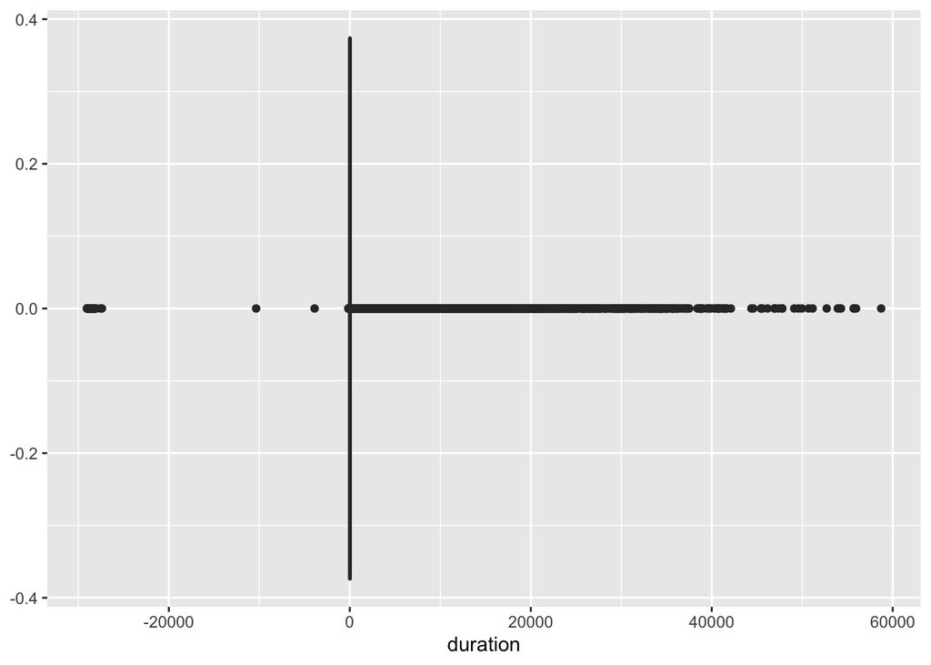

```r
# make boxplot of duration
ggplot(orig_df, mapping = aes(x = duration)) +
  geom_boxplot()
```

### Analysis

#### Ride Duration: Casual vs. Member

The bar graph below shows a comparison of the ride duration between casual and members. We see that the median duration for casual riders is ~16 minutes vs. ~10 minutes for members. This indicates casual riders tend to be visitors or occasional users that are less focused on time. Conversely, annual members tend to be city residents who use the service to bike to work and are more destination-oriented.

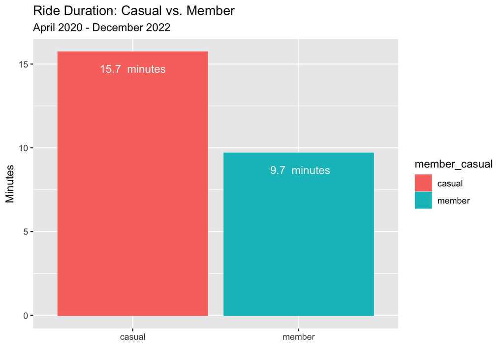

```r
ride_duration <- orig_df %>%
  group_by(member_casual) %>%
  summarize(
    median_duration = median(duration)
  )
ggplot(ride_duration,
  mapping = aes(x = member_casual, y = median_duration)) +
  geom_col(aes(color = member_casual, fill = member_casual)) +
  geom_text(aes(label = paste(format(median_duration, digits = 2), " minutes")), color = "white", nudge_y = -1) +
  labs(title = "Ride Duration: Casual vs. Member",
       subtitle = "April 2020 - December 2022",
       x = "", y = "Minutes")
```

#### Casual vs. Member: Day of Week

The bar graph of the percent of casual rides by day of the week is shown below. During the weekend, the % of casual rides is > 50%. As well, on Fridays, the percentage (43%) was elevated relative to the other weekdays. **This is another indication that a high proportion of casual riders are visitors to the city.**

```r
# calculate the total number of rides by day of the week
rides_by_day <- orig_df %>%
  group_by("day_of_week" = wday(started_at, label = TRUE, week_start = 1)) %>%
  summarize(
    day_count = n()
  )

# calculate the total number of casual rides by day of the week
casual_rides <- orig_df %>%
  filter(member_casual == "casual") %>%
  group_by("day_of_week" = wday(started_at, label = TRUE, week_start = 1)) %>%
  summarize(
    day_count = n()
  )

# calculate the % of casual rides
rides_by_day$casual_percent <- casual_rides$day_count / rides_by_day$day_count * 100
```

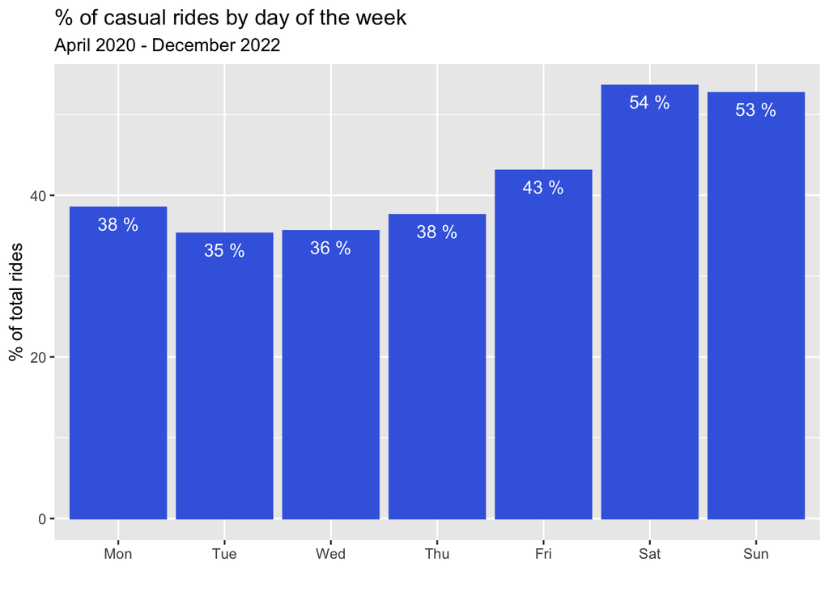

```r
ggplot(rides_by_day,
       mapping = aes(x = day_of_week, y = casual_percent)) +
  geom_col(color = "royalblue", fill = "royalblue") +
  geom_text(aes(label = paste(format(casual_percent, digits = 2), "%")),
            color = "white", nudge_y = -2) +
  labs(title = "% of casual rides by day of the week",
       subtitle = "April 2020 - December 2022",
       x = "", y = "% of total rides")
```

#### Casual % by month

Below is a line graph showing the percentage of casual riders per month from April 2020 to December 2022. There is a strong seasonal influence. During the winter months, there are < 30% of casual riders vs. 40-50% during other months, peaking in the summer (~50%). Year-to-year, the % of casual riders is roughly stable. The higher percentage of casual riders during spring, summer, and fall is probably due to visitors to the city. There may also be some residents who occasionally use the service during warmer months. **The takeway is that the summer months would be be the best time for a marketing campaign to casual riders.**

```r
# Create a new column for the start date with only the year and month
orig_df <- orig_df %>%
  mutate(
    start_year_month = format(started_at, "%Y-%m")
  )

# Count the number of rides per month and make sure the data is ordered by date
monthly_rides <- orig_df %>%
  group_by(start_year_month) %>%
  summarize(
    num_rides = n()
  ) %>%
arrange(start_year_month)

# Calculate the % of casual members by month
monthly_casuals <- orig_df %>%
  dplyr::filter(member_casual == "casual") %>%
  group_by(start_year_month) %>%
  summarize(
    num_casual_rides = n()
  ) %>%
arrange(start_year_month)
monthly_rides$percent_casual <-
  monthly_casuals$num_casual_rides / monthly_rides$num_rides * 100
```

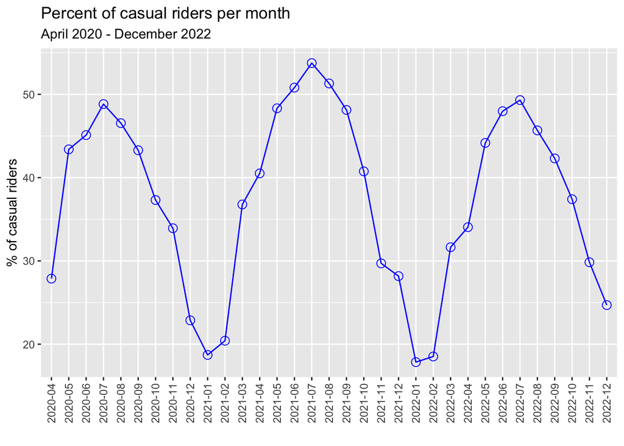

```r
ggplot(monthly_rides, mapping = aes(x = start_year_month, y = percent_casual, group = 1)) +
  geom_line(color = "blue") +
  geom_point(color = "blue", shape = 1, size = 3) +
  theme(axis.text.x = element_text(angle = 90, vjust = 0.5, hjust = 1)) +
  labs(title = "Percent of casual riders per month",
       subtitle = "April 2020 - December 2022",
       x = "", y = "% of casual riders")
```

### Summary and Recommendations

A high percentage of casual riders are visitors or residents who occasionally use the service mainly during warmer months. The main target of the marketing campaign should be residents who use the service enough to justify the purchase of an annual membership. The best time for the marketing campaign is from May - September, when a higher percentage of casual riders are using the service.

One way to market to casual riders is during the purchase process of a day pass or single ride. This is probably via a smartphone, either in a browser window or an app. A discount could be offered to encourage the user to sign up. Repeated day pass users could be presented with a limited time offer to apply their prior purchases to the purchase of an annual membership.

### Appendix: Additional Information

#### Ride Duration: Day of Week

Not surprisingly median durations are higher over the weekend, when many people are less hurried and there may be more tourist riders.

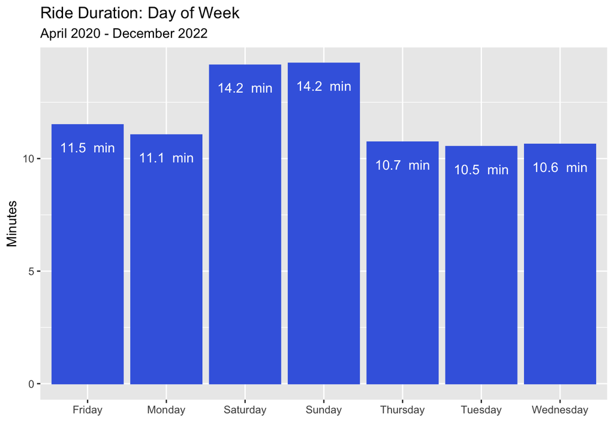

```r
# calculate the ride duration by day of the week
ride_duration_day <- orig_df %>%
  group_by("day_of_week" = weekdays(started_at)) %>%
  summarize(
    median_duration = median(duration)
  )

# Show a column graph of the median duration by day of the week
ggplot(ride_duration_day,
  mapping = aes(x = day_of_week, y = median_duration)) +
  geom_col(color = "royalblue", fill = "royalblue") +
  geom_text(aes(label = paste(format(median_duration, digits = 3), " min")), color = "white", nudge_y = -1) +
  labs(title = "Ride Duration: Day of Week",
       subtitle = "April 2020 - December 2022",
       x = "", y = "Minutes")
```

#### Number of Rides per Month

Show plot of number of rides per month from April 2020 to December 2022. There is a strong seasonal influence; fewer rides during winter months. Also, the number of rides increased from 2020 to 2021, and was stable in 2022.

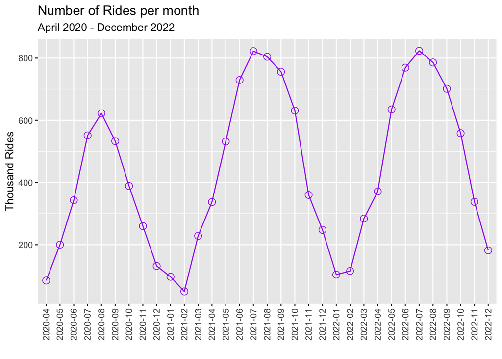

```r
ggplot(monthly_rides, mapping = aes(x = start_year_month, y = num_rides / 1000, group = 1)) +
  geom_line(color = "purple") +
  geom_point(color = "purple", shape = 1, size = 3) +
  theme(axis.text.x = element_text(angle = 90, vjust = 0.5, hjust = 1)) +
  labs(title = "Number of Rides per month",
       subtitle = "April 2020 - December 2022",
       x = "", y = "Thousand Rides")
```